# Statistiek - Lab session 5

J.F.P. (Richard) (s2956586)

Generated on: Fri Feb 22 01:03:47 2019

Beste heer/mevrouw,

In de studiehandleiding staat het volgende vermeld:

Wanneer de voorbereidende online vragenlijst tenminste 1 maand voor het eerste hoorcollege volledig is ingevuld, kan éénmalig een te laat ingeleverd verslag (welke wel is ingeleverd binnen een week na de deadline) nog steeds 2 punten krijgen bij een goede beoordeling en 1 punt bij een voldoende beoordeling. Wanneer een student van deze mogelijkheid gebruik wil maken, dient dit in het verslag aangegeven te worden. Het invullen van de online vragenlijst geeft dus eenmalig extra tijd voor een practicum.

Graag wil ik gebruik maken van deze optie. Vanwege de griep was ik niet in staat de opdrachten af te krijgen. Nu wil ik ze alsnog in leveren onder bovenstaande richtlijnen.

Met vriendelijke groet,

J.F.P. (Richard) Scholtens s2956586

```r
download.file('http://www.let.rug.nl/wieling/Statistiek-I/dat.rda','dat.rda')
load('dat.rda',verbose=T) # load population data
```

```
## Loading objects:
##   dat
```

```r
set.seed(74)

# Subset data to 16 people without bilingual education (random selection)
bl_no <- dat[dat$participant %in% sample(dat[dat$bl_edu=='N',]$participant,16),]

# Subset data to 16 people with bilingual education (random selection)
bl_yes <- dat[dat$participant %in% sample(dat[dat$bl_edu=='Y',]$participant,16),]

# create a new dataframe by combining the two subsets
smp <- rbind(bl_no, bl_yes)
str(smp)
```

```
## 'data.frame':    32 obs. of  18 variables:
##  $ participant         : int  7 15 62 67 149 182 185 213 220 230 ...
##  $ year                : num  2017 2017 2017 2017 2016 ...
##  $ study               : Factor w/ 4 levels "CIS","IS","LING",..: 3 4 1 1 3 3 3 3 4 3 ...
##  $ edu_level           : Factor w/ 3 levels "HAVO","VWO","HBO": 2 2 3 3 1 3 3 1 2 2 ...
##  $ gender              : Factor w/ 2 levels "F","M": 1 1 1 1 1 1 1 1 1 1 ...
##  $ hand                : Factor w/ 2 levels "R","L": 1 1 1 1 1 2 2 1 1 1 ...
##  $ instrument          : Factor w/ 2 levels "Y","N": 2 1 1 2 2 2 1 2 1 1 ...
##  $ bl_edu              : Factor w/ 2 levels "Y","N": 2 2 2 2 2 2 2 2 2 2 ...
##  $ l1cnt               : num  1 1 1 1 1 1 1 1 1 1 ...
##  $ l2cnt               : num  1 1 1 1 2 1 2 1 2 1 ...
##  $ age_listening       : num  11 10 10 10 8 10 11 11 10 12 ...
##  $ age_reading         : num  11 8 11 10 10 10 12 12 10 14 ...
##  $ age_speaking        : num  12 12 10 10 10 10 12 12 10 13 ...
##  $ age_writing         : num  12 12 11 10 10 11 12 13 10 15 ...
##  $ accent_strength_self: num  4 5 6 5 3 5 4 7 5 6 ...
##  $ english_grade       : num  7 8 6 7 7 6 6 7 7 7 ...
##  $ english_score_self  : num  7.5 9 7 6.75 9 6.5 7 7.5 7.25 7.25 ...
##  $ english_score       : num  6.78 8.45 6.33 6.01 7.53 ...
```

# 1 Exercise 1

```r
table(smp$bl_edu)
```

```
##
##  Y  N
## 16 16
```

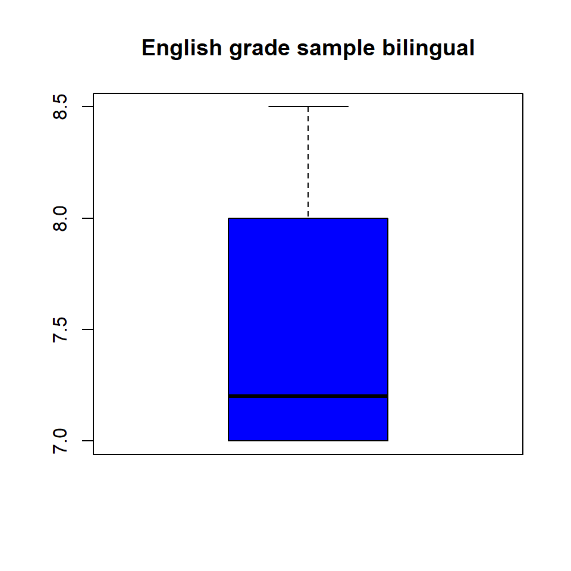

```r
smp_bl_y <- smp[smp$bl_edu == "Y", ]
smp_bl_n <- smp[smp$bl_edu == "N", ]
boxplot(smp_bl_y$english_grade, main="English grade sample bilingual", col="blue")
```

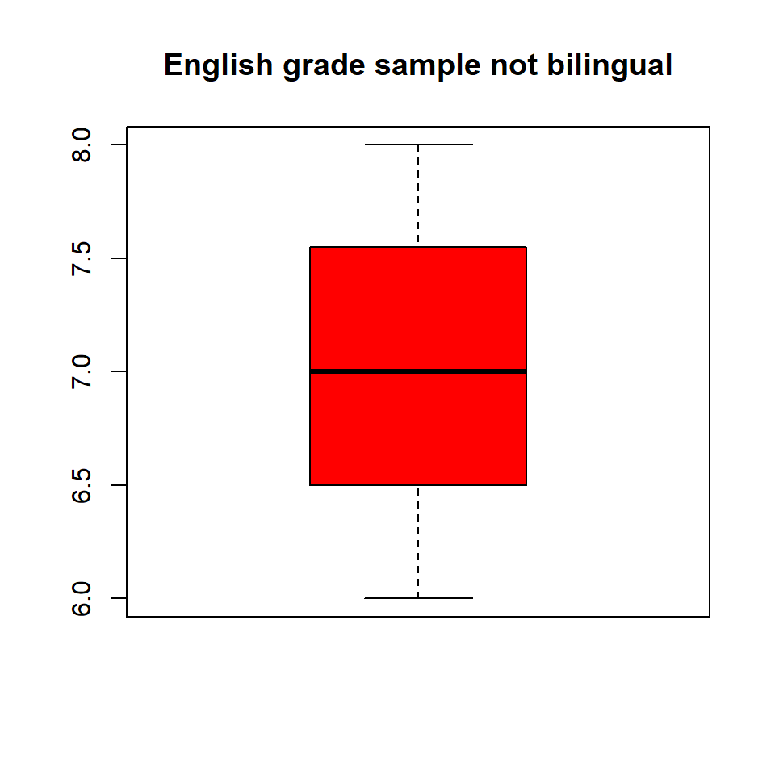

```r
boxplot(smp_bl_n$english_grade, main="English grade sample not bilingual", col="red")
```

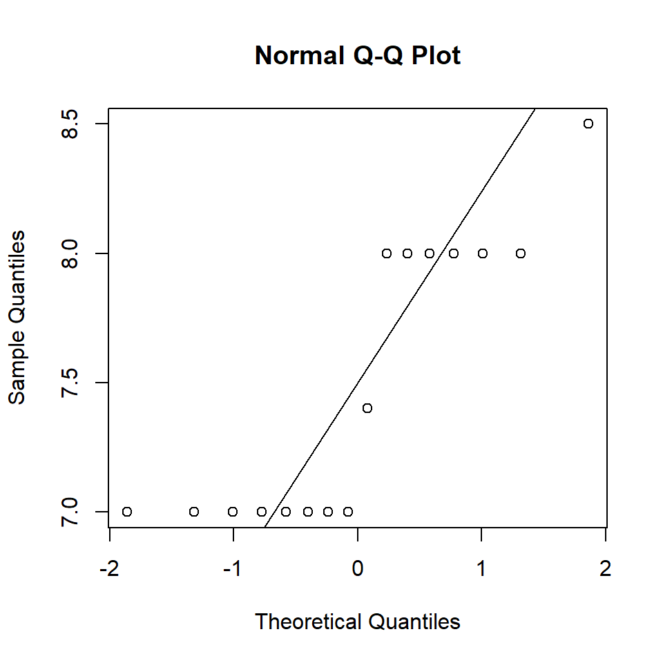

```r
qqnorm(smp_bl_y$english_grade)
qqline(smp_bl_y$english_grade)
```

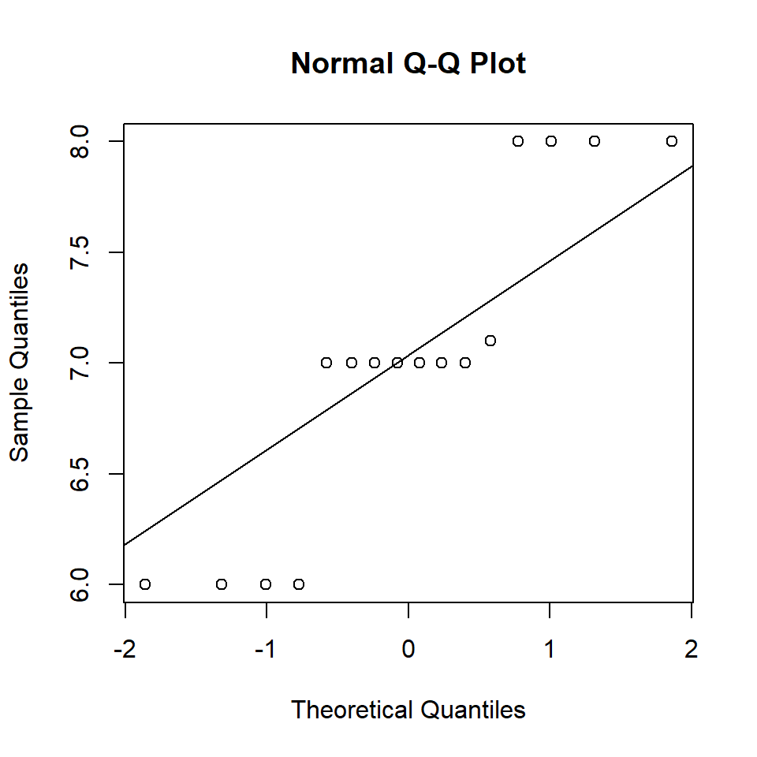

```r
qqnorm(smp_bl_n$english_grade)
qqline(smp_bl_n$english_grade)
```

```r
shapiro.test(smp_bl_y$english_grade)
```

```
##
##  Shapiro-Wilk normality test
##
## data:  smp_bl_y$english_grade
## W = 0.75565, p-value = 0.0007437
```

```r
shapiro.test(smp_bl_n$english_grade)
```

```
##
##  Shapiro-Wilk normality test
##
## data:  smp_bl_n$english_grade
## W = 0.82798, p-value = 0.006569
```

```r
wilcox.test(smp_bl_y$english_grade, smp_bl_n$english_grade, alternative = "greater")
```

```
##
##  Wilcoxon rank sum test with continuity correction
##
## data:  smp_bl_y$english_grade and smp_bl_n$english_grade
## W = 172, p-value = 0.03899
## alternative hypothesis: true location shift is greater than 0
```

```r
library(effsize)
cliff.delta(smp_bl_y$english_grade, smp_bl_n$english_grade)
```

```
##
## Cliff's Delta
##
## delta estimate: 0.34375 (medium)
## 95 percent confidence interval:
##         inf         sup
## -0.04104667  0.63974823
```

We obtained English scores in a sample of 316 students of the Statistiek 1 course via an online questionnaire(222F, 93M). From those groups we got a sample from 32 random students. 16 of those students are bilingual and 16 are not.

H0: The english grades of bilingual students are not significantly higher than those of non bilangual students. Ha: The english grades of bilingual students are significantly higher than those of non bilangual students.

H0: $\mu$bl_y = $\mu$bl_n

Ha: $\mu$bl_y > $\mu$bl_n

Significance level: = 0.05

The shapiro test concludes that the p-values are below the significance level of 0.05 so the samples deviate from normality. Because the samples are not normally distributed we use the Mann-Whitney U test to analyze the difference between the two groups.

W/U= 172 p = 0.03899

The p-level is lower than the significance level. Therefor H0 will be rejected, and Ha will be accepted.

The cliff delta test has been used to asses the effectsize of the non parametric test. It says the effectsize is medium spread so we must take in account these results.

Conclusion:

We must accept the alternative statement and take the results seriously. This means the bilangual students could be significantly better in the English language than students who do not study bilingual.

# 2 Exercise 2

```r
wilcox.test(smp_bl_y$english_grade, smp_bl_n$english_grade)
```

```
##
##  Wilcoxon rank sum test with continuity correction
##
## data:  smp_bl_y$english_grade and smp_bl_n$english_grade
## W = 172, p-value = 0.07799
## alternative hypothesis: true location shift is not equal to 0
```

```r
cliff.delta(smp_bl_y$english_grade, smp_bl_n$english_grade)
```

```
##
## Cliff's Delta
##
## delta estimate: 0.34375 (medium)
## 95 percent confidence interval:
##         inf         sup
## -0.04104667  0.63974823
```

We obtained English scores in a sample of 316 students of the Statistiek 1 course via an online questionnaire(222F, 93M). From those groups we got a sample from 32 random students. 16 of those students are bilingual and 16 are not.

H0: The english grades of bilingual students are not significantly different than those of non bilangual students. Ha: The english grades of bilingual students are significantly different than those of non bilangual students.

H0: $\mu$bl_y = $\mu$bl_n

Ha: $\mu$bl_y $\neq$ $\mu$bl_n

Significance level: = 0.05

The shapiro test concludes that the p-values are below the significance level of 0.05 so the samples deviate from normality. Because the samples are not normally distributed we use the Mann-Whitney U test to analyze the difference between the two groups.

W/U= 172 p = 0.07799

The p-level is higher than the significance level. Therefor H0 will not be rejected

The cliff delta test has been used to asses the effectsize of the non parametric test. It says the effectsize is medium spread so we must take in account these results.

Conclusion:

We do not reject the HO statement. This means the bilangual students grades are not significantly different in the English language than students who do not study bilingual.

# 3 Exercise 3

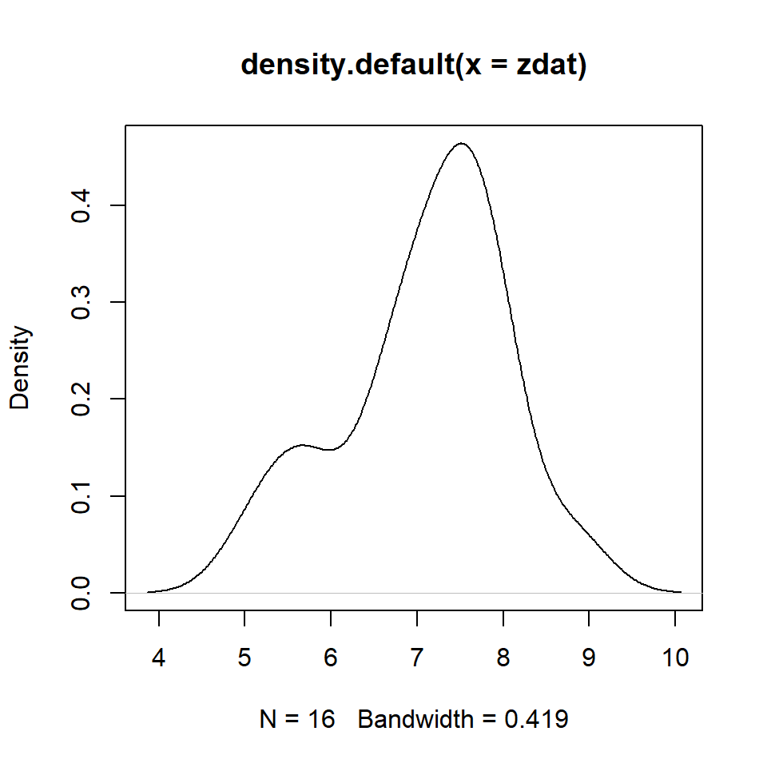

```r
smp_n_eg <- smp[smp$bl_edu=='N',]$english_grade
m_bl_n <- mean(smp_n_eg)
zdat <- rnorm(mean=m_bl_n, n=16)
plot(density(zdat))
```

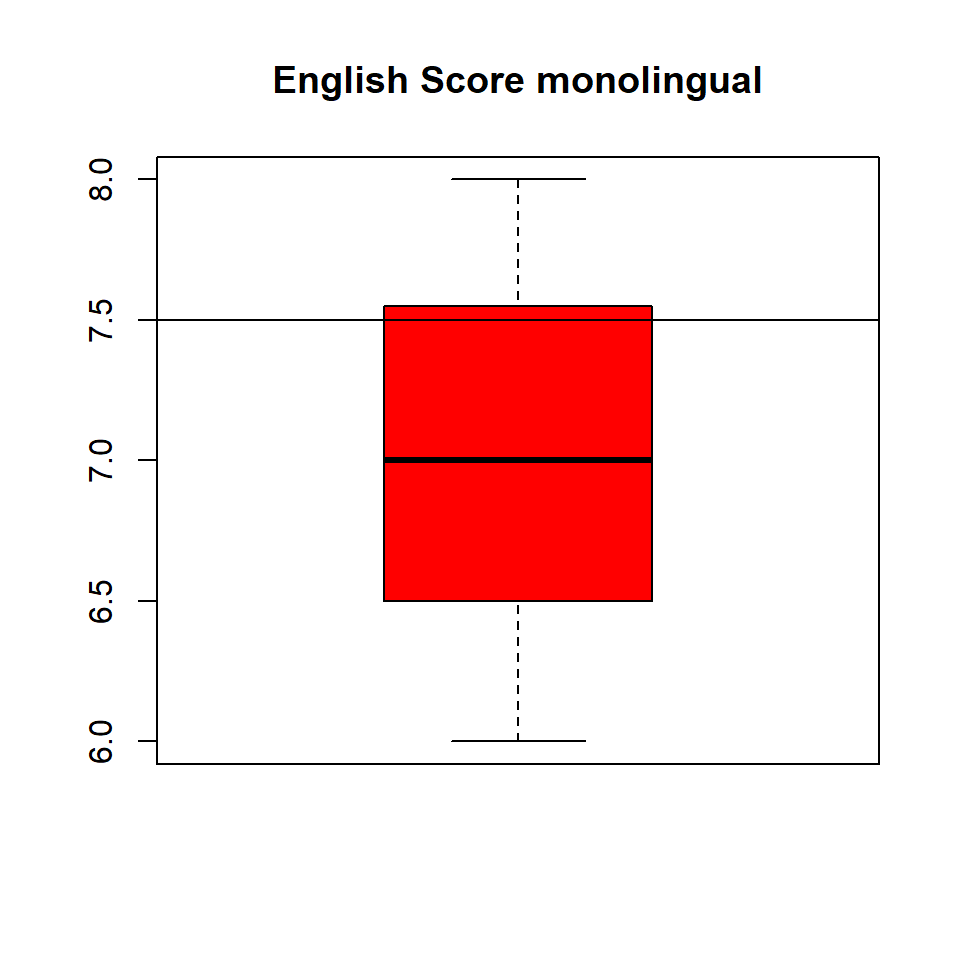

```r
boxplot(smp_n_eg, main="English Score monolingual", col="red")
abline(h=7.5)
```

```r
wilcox.test(dat$english_score, alternative = "two.sided", mu = 7.5)
```

```
##
##  Wilcoxon signed rank test with continuity correction
##
## data:  dat$english_score
## V = 21424, p-value = 0.03243
## alternative hypothesis: true location is not equal to 7.5
```

```r
pval <- wilcox.test(dat$english_score, alternative = "two.sided", mu = 7.5)$p.value
zval <- qnorm(pval/2, lower.tail = FALSE)  # pval/2 because of two-tailed test
n <- nrow(dat)
(effectsize <- zval/sqrt(n))
```

```
## [1] 0.1205246
```

We obtained English scores in a sample of 316 students of the Statistiek 1 course via an online questionnaire(222F, 93M). From those groups we got a sample from 32 random students. 16 of those students are bilingual and 16 are not. We use the Wilcox signed rank-test because the because the density plot is roughly symmetric and we use the same subjects.

H0: $\mu$ = 7.5

Ha: $\mu$ $\neq$ 7.5

Significance level: = 0.05

V = 21424 p = 0.03243

The p-level is lower than the significance level. Therefor H0 will be rejected, and Ha will be accepted.

The effect size is 0.1205246 wich means it is worth looking at.

# 4 Exercise 4

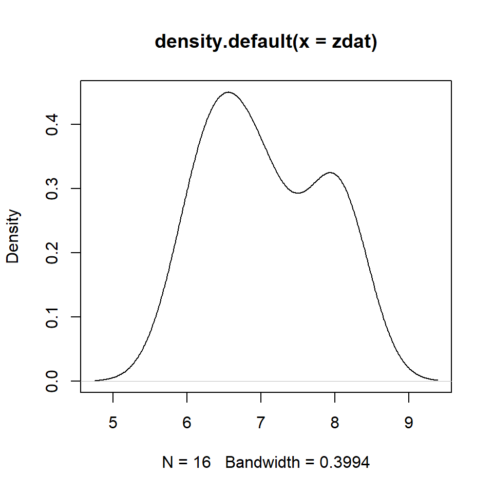

```r
smp_y_eg <- smp[smp$bl_edu=='Y',]$english_grade
m_bl_y <- mean(smp_y_eg)
zdat <- rnorm(mean=m_bl_y, n=16)
plot(density(zdat))
```

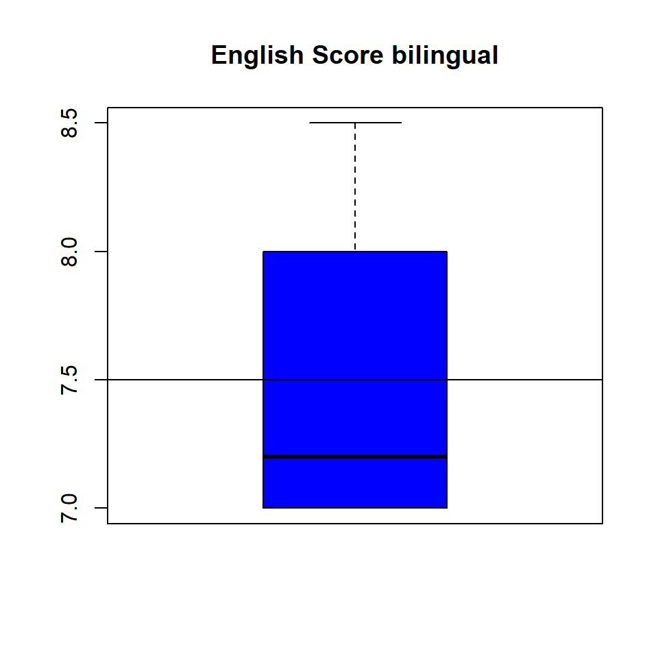

```r
boxplot(smp_y_eg, main="English Score bilingual", col="blue")
abline(h=7.5)
```

```r
signs <- sign(bl_yes$english_grade - 7.5)

plus_sign <- sum(signs ==1)
plus_sign
```

```
## [1] 7
```

```r
min_sign <- sum(signs ==-1)
min_sign
```

```
## [1] 9
```

```r
max_sign <- sum(plus_sign + min_sign)
max_sign
```

```
## [1] 16
```

```r
binom.test(x = min_sign, n = max_sign, p = 0.5, alternative = "two.sided")
```

```
##
##  Exact binomial test
##
## data:  min_sign and max_sign
## number of successes = 9, number of trials = 16, p-value = 0.8036
## alternative hypothesis: true probability of success is not equal to 0.5
## 95 percent confidence interval:
##  0.2987769 0.8024659
## sample estimates:
## probability of success
##                 0.5625
```

```r
pval3 <- binom.test(x = min_sign, n = max_sign, p = 0.5, alternative = "two.sided")$p.value
zval3 <- qnorm(pval3/2, lower.tail = FALSE)  # pval/2 because of two-tailed test
n <- nrow(dat)
(effectsize <- zval3/sqrt(n))
```

```
## [1] 0.01401072
```

We obtained English scores in a sample of 316 students of the Statistiek 1 course via an online questionnaire(222F, 93M). From those groups we got a sample from 32 random students. 16 of those students are bilingual and 16 are not. We use the sign-test because the because the density plot isn’t symmetric.

H0: The english grades of bilingual students are not significantly different than 7.5. Ha: The english grades of bilingual students are significantly different 7.5.

H0: $\mu$ = 7.5

Ha: $\mu$ $\neq$ 7.5

Significance level: = 0.05

p = 0.8036

The p-level is higher than the significance level. Therefor H0 will not be rejected.

The effect size is 0.01401072 wich means it isn’t worth looking at.

Conclusion:

We do not reject the HO statement. This means the bilangual students english grades are not significantly different than 7.5.

# 5 Exercise 5

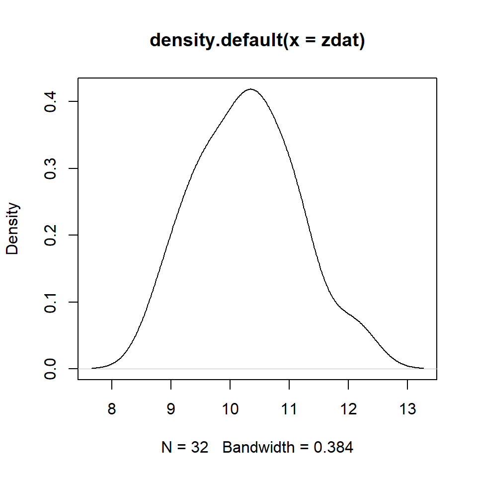

```r
age_write <- smp$age_writing

age_speak <- smp$age_speaking

m_age_wr <- mean(age_write)
m_age_sp <- mean(age_speak)


zdat <- rnorm(mean=m_age_wr, n=32)
plot(density(zdat))
```

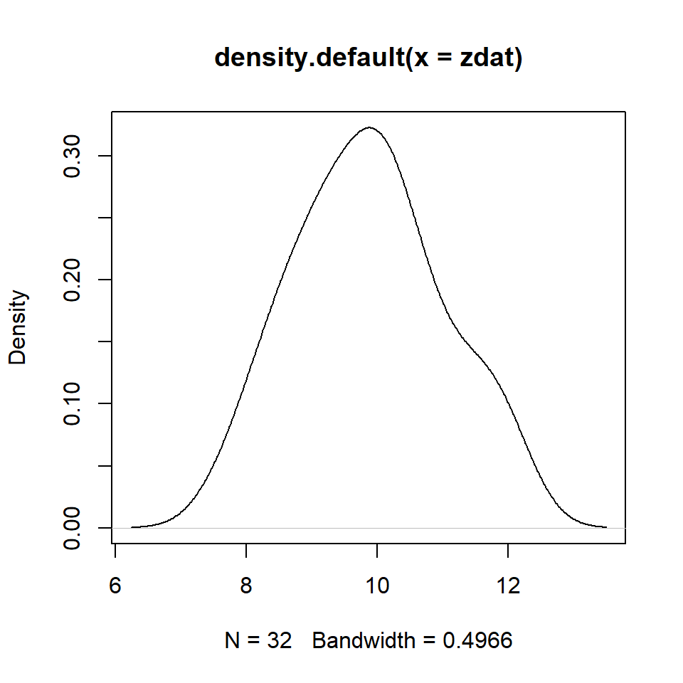

```r
zdat <- rnorm(mean=m_age_sp, n=32)
plot(density(zdat))
```

```r
wilcox.test(age_write, age_speak, alternative = "two.sided")
```

```
##
##  Wilcoxon rank sum test with continuity correction
##
## data:  age_write and age_speak
## W = 567, p-value = 0.4445
## alternative hypothesis: true location shift is not equal to 0
```

```r
cliff.delta(age_write, age_speak)
```

```
##
## Cliff's Delta
##
## delta estimate: 0.1074219 (negligible)
## 95 percent confidence interval:
##        inf        sup
## -0.1677614  0.3670749
```

H0: The age of writing of english is not significantly different than the age of speaking english. Ha: The age of writing of english is significantly higher than the age of speaking english.

H0: $\mu$wr = $\mu$sp

Significance level: = 0.05

W / U = 567 p = 0.4445

The p-level is higher than the significance level. Therefor H0 will not be rejected.

The effect size is 0.1074219 wich means it isn’t worth looking at.

Conclusion:

We do not reject the HO statement. This mean the age of writing english isn’t significantly higher than the age of speaking english.

# 6 Exercise 6

```r
t.test(age_speak, age_write, alternative = "greater", paired = TRUE)
```

```
##
##  Paired t-test
##
## data:  age_speak and age_write
## t = -2.1559, df = 31, p-value = 0.9805
## alternative hypothesis: true difference in means is greater than 0
## 95 percent confidence interval:
##  -0.6140889        Inf
## sample estimates:
## mean of the differences
##                -0.34375
```

```r
cohen.d(age_speak, age_write, paired = TRUE)
```

```
##
## Cohen's d
##
## d estimate: -0.38112 (small)
## 95 percent confidence interval:
##        inf        sup
## -0.8853793  0.1231392
```

We obtained English scores in a sample of 316 students of the Statistiek 1 course via an online questionnaire(222F, 93M). From those groups we got a sample from 32 random students. 16 of those students are bilingual and 16 are not. We use the t-test because the data is symmetric.

H0: The age of writing of english is not significantly different than the age of speaking english. Ha: The age of writing of english is significantly higher than the age of speaking english.

H0: $\mu$wr = $\mu$sp

This hypothesis is tested with a paired T-test. Significance level: 0.05: p = 0.9805

The p-level is higher than the significance level. Therefor we do not reject H0.

Cohen’s d estimate: -0.38112 (small)

Significance level: 0.05:

The effectsize is small and therefor not important.